# Class 01: An introductory data wrangling and description example

William Mechler

## Preliminaries

Before getting started we need to give credit where credit is due. A special thanks to Mine Cetinkaya-Rundel from Duke University for the idea and outlines of this first assignments.

## Opening question

Today we will look at the voting history of countries in the United Nations General Assembly. We will be using data from the `unvotes` package. Additionally, we will make use of the `tidyverse` and `lubridate` packages.

```r
library(unvotes)
library(tidyverse)
library(lubridate)
```

## Data

We have three datasets we can work with: `un_roll_calls`, `un_roll_call_issues`, and `un_votes`. Each of these datasets contains a variable called `rcid`, the roll call id, which can be used to join them with each other.

- The `un_votes` dataset provides information on the voting history of the United Nations General Assembly. It contains one row for each country-vote pair.

```r
un_votes
```

```
## # A tibble: 738,764 x 4
##     rcid country                  country_code vote
##    <int> <chr>                    <chr>        <fct>
##  1     3 United States of America US           yes
##  2     3 Canada                   CA           no
##  3     3 Cuba                     CU           yes
##  4     3 Haiti                    HT           yes
##  5     3 Dominican Republic       DO           yes
##  6     3 Mexico                   MX           yes
##  7     3 Guatemala                GT           yes
##  8     3 Honduras                 HN           yes
##  9     3 El Salvador              SV           yes
## 10     3 Nicaragua                NI           yes
## # ... with 738,754 more rows
```

- The `un_roll_calls` dataset contains information on each roll call vote of the United Nations General Assembly.

```r
head(un_roll_calls)
```

```
## # A tibble: 6 x 9
##    rcid session importantvote date       unres  amend  para short   descr
##   <int>   <dbl>         <dbl> <date>     <chr>  <dbl> <dbl> <chr>   <chr>
## 1     3       1             0 1946-01-01 R/1/66     1     0 AMENDM~ "TO ADOPT A~
## 2     4       1             0 1946-01-02 R/1/79     0     0 SECURI~ "TO ADOPT A~
## 3     5       1             0 1946-01-04 R/1/98     0     0 VOTING~ "TO ADOPT T~
## 4     6       1             0 1946-01-04 R/1/1~     0     0 DECLAR~ "TO ADOPT A~
## 5     7       1             0 1946-01-02 R/1/2~     1     0 GENERA~ "TO ADOPT A~
## 6     8       1             0 1946-01-05 R/1/2~     1     0 ECOSOC~ "TO ADOPT A~
```

- The `un_roll_call_issues` dataset contains (topic) classifications of roll call votes of the United Nations General Assembly. Many votes had no topic, and some have more than one.

```r
tail(un_roll_call_issues)
```

```
## # A tibble: 6 x 3
##    rcid short_name issue
##   <int> <chr>      <chr>
## 1  5137 ec         Economic development
## 2  5304 ec         Economic development
## 3  5460 ec         Economic development
## 4  4816 ec         Economic development
## 5  3497 ec         Economic development
## 6  5393 ec         Economic development
```

## Analysis

### Larger comparison example

First, let’s take a look at how often each country voted “yes” on a resolution in each year. We’ll visualize the results, so let’s pick a few countries of interest first,

```r
country_list <- c("United States of America", "China", "Mexico", "Canada")
```

and focus our analysis on them. In this first *chunk* of code we bring together the `un_votes` dataset with the `un_roll_calls` dataset linking by the `rcid` variable (this is the `inner_join` call). The `filter()` statement limits our data to the countries of interest. The `group_by()` and `summarize()` functions calculate the number of `votes` and the percentage of times a country voted “yes” for each country per year. Lastly we take a sneak peak at our summarized data with the `glimpse()` function.

```r
un_vote.trim <- un_votes %>%
  filter(country %in% country_list) %>%
  inner_join(un_roll_calls, by = "rcid") %>%
  group_by(Year = year(date), country) %>%
  summarize(votes = n(),
            percent_yes = mean(vote == "yes"))
glimpse(un_vote.trim)
```

```
## Rows: 252
## Columns: 4
## Groups: Year [69]
## $ Year        <dbl> 1946, 1946, 1946, 1947, 1947, 1947, 1948, 1948, 1948, 1...
## $ country     <chr> "Canada", "Mexico", "United States of America", "Canada...
## $ votes       <int> 42, 38, 43, 38, 38, 38, 64, 63, 64, 104, 94, 104, 50, 5...
## $ percent_yes <dbl> 0.6428571, 0.6842105, 0.6046512, 0.6052632, 0.6315789, ...
```

Now that we have the data as we way, we can plot it. In the code below note that we are letting the Country determine the color of the line.

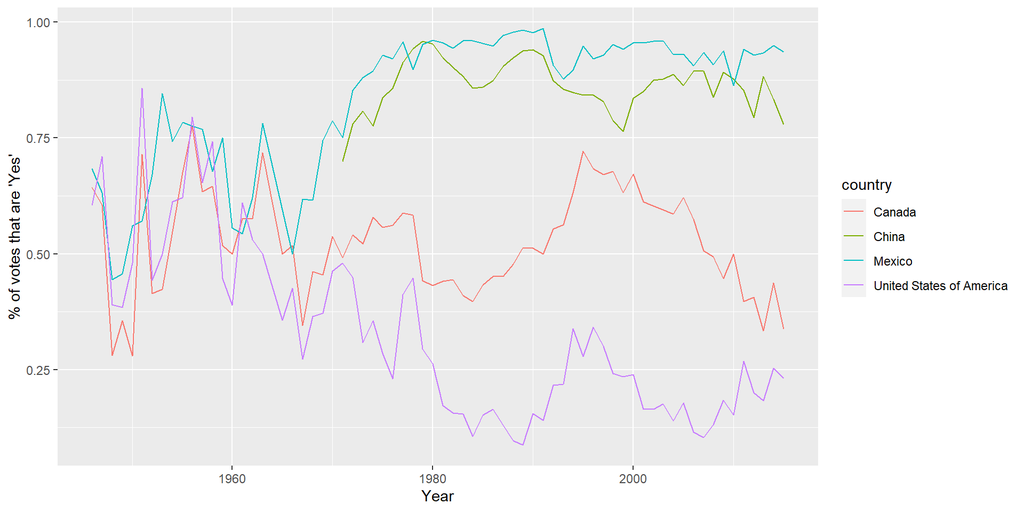

Figure 1: UN voting records over time for 4 countries. The four lines are close together until the late 1960s, but after that they gradually split with Mexico at about 90%, China at about 80%, Canada at about 50%, and the US at about 20% over the last 50 years.

```r
ggplot(un_vote.trim, aes(x = Year, y = percent_yes, color = country)) +
  geom_line() +
  ylab("% of votes that are 'Yes'")
```

#### Discussion

What do you notice about the difference in the countries?

### Comparison of two countries

Next, let’s see how *United Kingdom of Great Britain and Northern Ireland* and *France*’s voting record changed over the years on each of the issues.

```r
un.compare <- un_votes %>%
  filter(country %in% c("United Kingdom of Great Britain and Northern Ireland", "France")) %>%
  inner_join(un_roll_calls, by = "rcid") %>%
  inner_join(un_roll_call_issues, by = "rcid") %>%
  group_by(country, Year = year(date), issue) %>%
  summarize(votes = n(),
            percent_yes = mean(vote == "yes")) %>%
  filter(votes > 10 & Year > 2000)    # Only use records where there are more than 5 votes
```

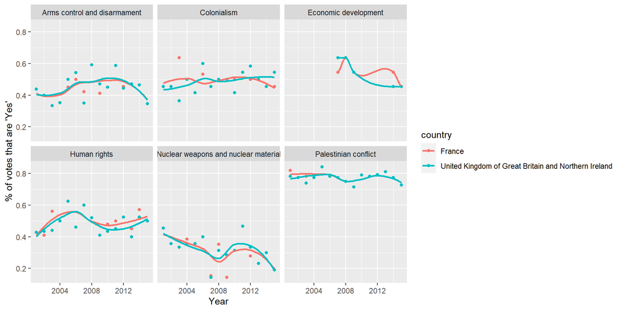

```r
ggplot(un.compare, aes(x = Year, y = percent_yes, color = country)) +
  geom_point() +
  geom_smooth(method = "loess", se = FALSE) +
  facet_wrap(~ issue) +
  ylab("% of votes that are 'Yes'")
```

## Now it’s your turn!!!

### Part 0

Change the line at the top of this file labeled “author:” to match your name and those of your teammates.

### Part 1

Pick two other countries (the full list is below) besides the *United States of America* and *China*. Write in which two countries you chose and why you picked them.

**I picked United Kingdom of Great Britain and Northern Ireland and France. Because they are both in Europe and are a part of the EU, however the UK is planning to leave the EU. I wanted to see if their differences in the EU come across in their UN voting habits.**

### Part 2

Edit the code in the “Comparison of two countries” part of this document to do the following:

- Compare the two countries you chose
- Filter the data such that it is only plotted if:
  - there was more than 10 votes
  - The `Year` is after the year 2000

### Part 3

Compare contrast the two countries you chose. Does anything seem surprising in their voting tendencies? Discuss!

**Not really we see that they both seem to vote in the same manner for most of the votes. But the interesting part is under the Economic Development graph were they seem to disagree. This was expected because one of the many reasons for the UK to leave the EU has to do with the market of Europe to majorly oversimplify.**

### Part 4

*Knit* the document once more and submit the *html* file through the canvas site.

## References

1. David Robinson (2017). unvotes: United Nations General Assembly Voting Data. R package version 0.2.0. https://CRAN.R-project.org/package=unvotes.
2. Erik Voeten “Data and Analyses of Voting in the UN General Assembly” Routledge Handbook of International Organization, edited by Bob Reinalda (published May 27, 2013).
3. Much of the analysis has been modeled on the examples presented in the [unvotes package vignette](https://cran.r-project.org/web/packages/unvotes/vignettes/unvotes.html).

## Appendix

Below is a list of countries in the dataset:

```r
un_votes %>%
  arrange(country) %>%
  select(country) %>%
  distinct() %>%
  as.data.frame()
```

```
##                                                  country
## 1                                            Afghanistan
## 2                                                Albania
## 3                                                Algeria
## 4                                                Andorra
## 5                                                 Angola
## 6                                    Antigua and Barbuda
## 7                                              Argentina
## 8                                                Armenia
## 9                                              Australia
## 10                                               Austria
## 11                                            Azerbaijan
## 12                                               Bahamas
## 13                                               Bahrain
## 14                                            Bangladesh
```

[output cut: 186 more lines]